# (Ford-GoBike Share)

## by (Mohamed Hamdy)

## Investigation Overview

> We are going to do some analysis on the bike share dataset for Feb-2019, using charts and some statistics to figure when, where, and what kind of users whether subscriber membership or normal customers through all genders and their relation to the spent duration, and are there any relationship between these features and are they affect the duration spent during trip.

## Dataset Overview

> This data set includes information about individual rides made through a bike-sharing system covering the greater San Francisco Bay area. Time and dates at which riders used to go on a ride, also some members identifications like age, gender and membership status are included as well for each member.

## Univariate Exploration

##### What are the most common start stations riders begin from?

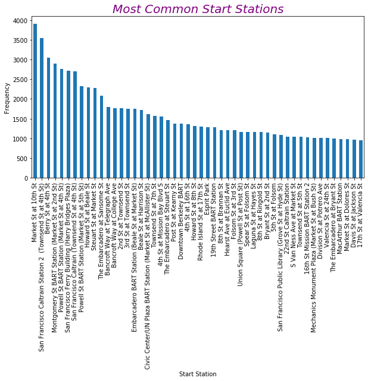

#### Here are the first 50 most common start stations found in the dataset, with the most common one is(Market st at 10th st)

##### what is the most common end station?

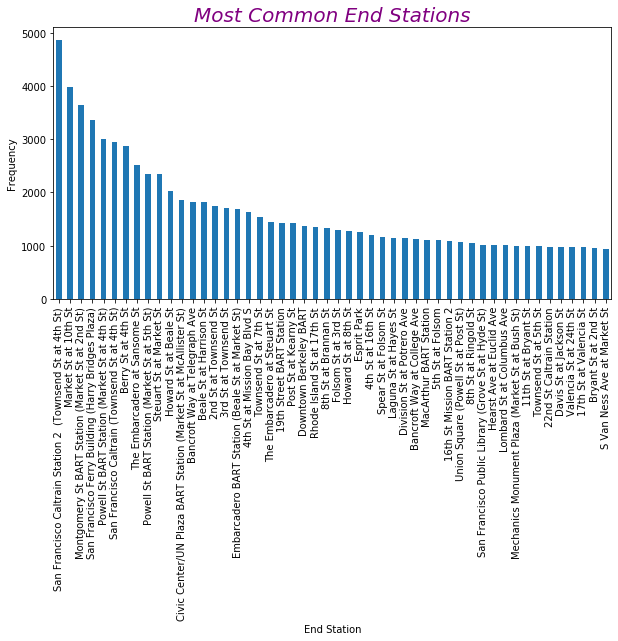

#### Here are the first 50 most common end stations found in the dataset, and the most common end station is (San Franscisco station2-Townsend sr at 4th st)

##### What is the average duration bikers used to spent during this month ?

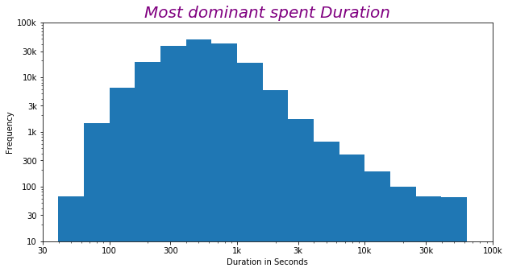

#### Most duration falls in the zone between (300 - 2000 sec)

##### what is the mean age for the participated riders?

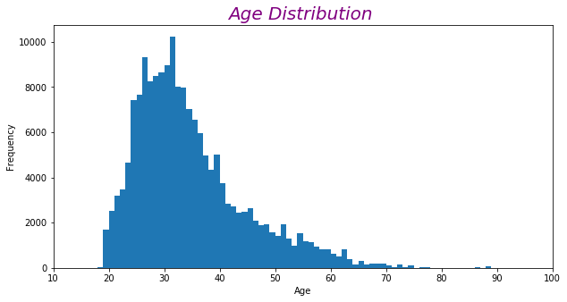

#### The age of most bikers falls in the range between 25 and 34 years old, with mean 34 years old

##### whats is the count of Males and Females contributed in the bike share?

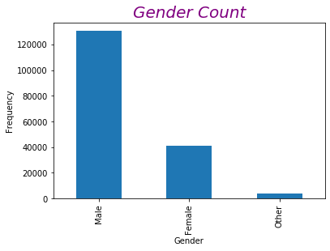

#### Appears that male has the most dominant count over females and other gender type

##### Showing the percentage of each gender in the bike share

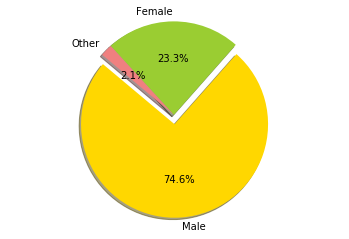

#### Obviously the male has the most dominant count over female and other in this dataset, in the next plots we will consider this difference and see what if this male count dmoinancy has the same high frequency according to the other factors like duration of the trip

##### What are the most common starting hours, riders used to go on ?

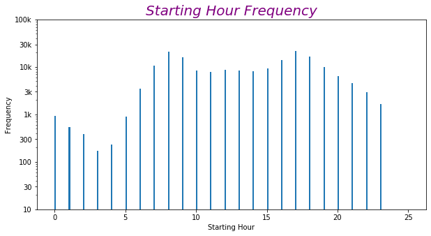

#### As noticed that the most common starting hours is 8 Am, and 5 Pm

##### What are the most common days riders used to go on ?

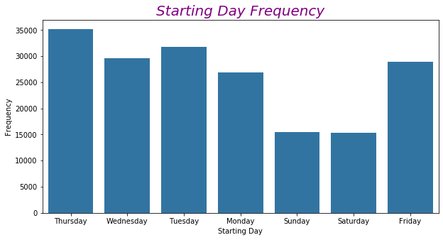

#### From the above counplot we can see the frequency of each day in the week, obviously Thursday and Tuesday are the most common days bikers go on.

##### What is the percentage of user types in this bike share?

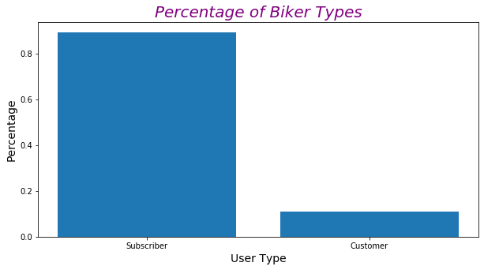

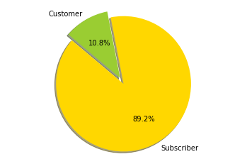

#### Subscriber riders are the dominant user type in this data set, about 90 % of all members are subscribers

## Bivariate Exploration

#### Now we are going two see some cominations of the available features

#### What gender type spent the most duration during rides ?

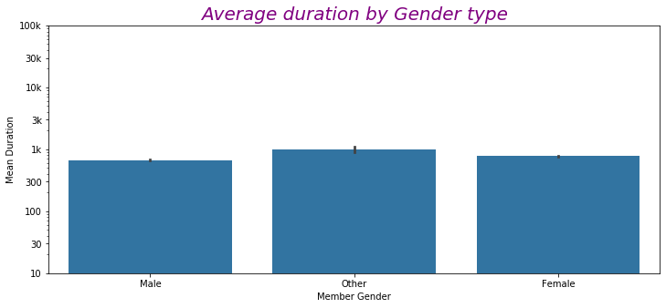

#### From the plot we can observe that other and female gender type did spend more duration time than males

##### What days at which most spent duration recorded ?

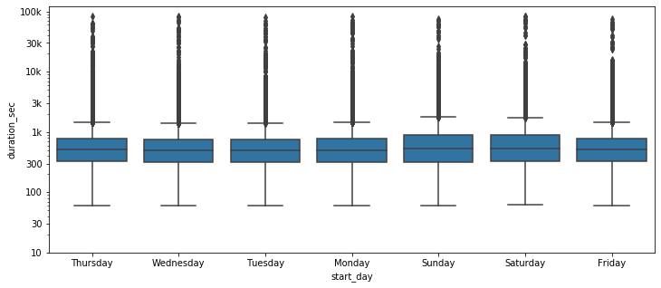

#### Sunday and Saturday are the most days that have the highest duration trip times followed by Thursday, we are going to contribute this later with gender type and user type to see what generes are making this high variance in these two days

##### What age range has spent higher duration through bike share ?

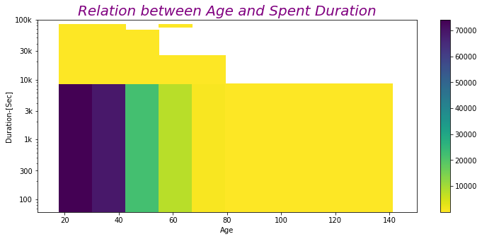

##### Another plot for age and spent duration

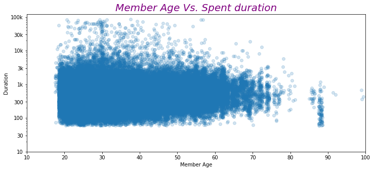

#### Apparently we can see that younger the age the more time being spent on the ride, the upper left corner of the plot is more dense than the rest of the plot which means young and high duration time.

##### Is user type influenced by member gender ?

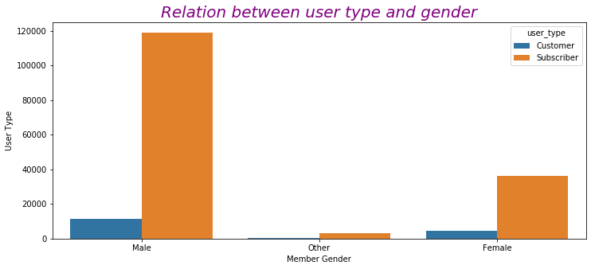

#### From the relationship between user type and gender, we found out that male subscribers are the most dominant here in the dataset comparing to the customers, same for female and others.

##### Is certain user type preferes certain days, most common days for both types if different ?

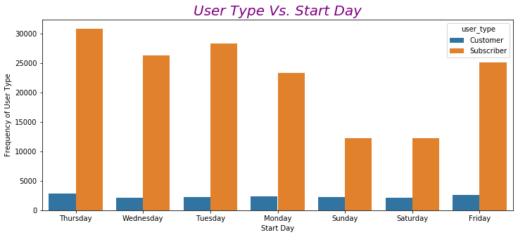

#### As noticed from the plot that most common days for subscribers to go on a ride are Thursday and Tuesday , and for customer are Thursday and Friday.

##### Is there common days for certain genders ?

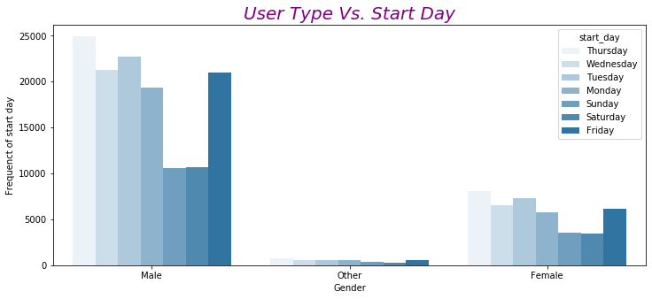

#### Most common days for Males and Females are Thursday and Tuesday, for others Thursdays

##### which user types made higher duration times through these trips?

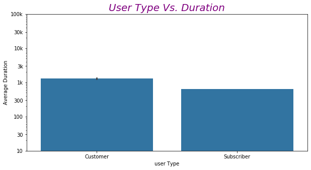

#### From the above plot Customer user type has more spent duration than subscriber user type.However, we have much more subscribers than customers

### We are going to create a new column for age category which will be categorial type

##### Does certain age category involved with different start days than other categories?

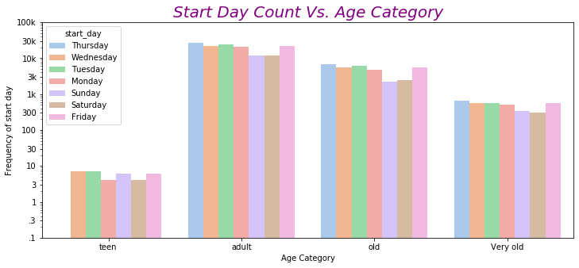

##### What is the count of subscribers and customers in each age cateorgy ?

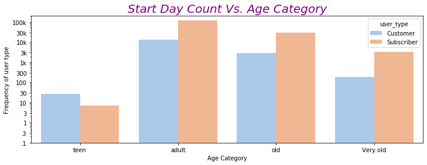

#### From this plot, all age groups have higher subscribers than customers except for teens category customers number is higher

##### Does starting from a specific hours influence the trip duration ?

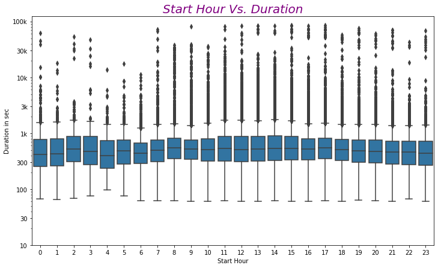

##### Does certain start locations lead to higher duration times ?

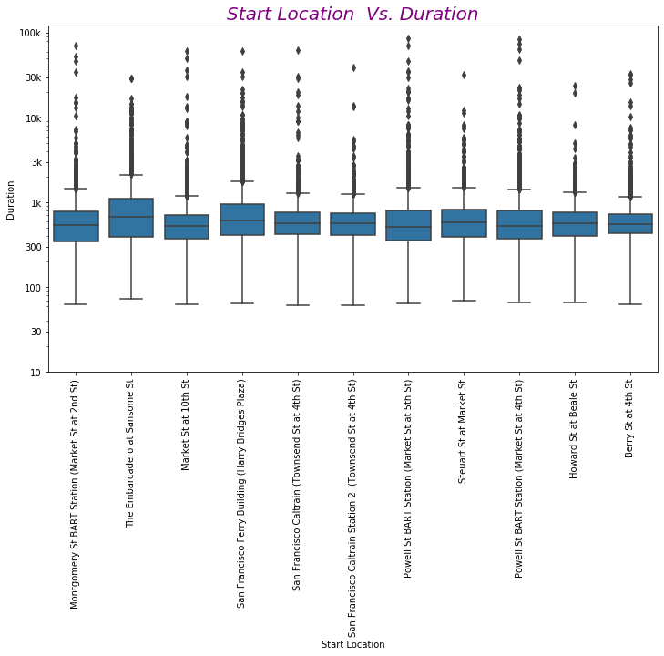

## Multivariate Exploration

#### let's Check after we found out that sunday an saturday are the days that has the most spent duration and from univariate gender type plot we found that other gender has the most spent duration as well.

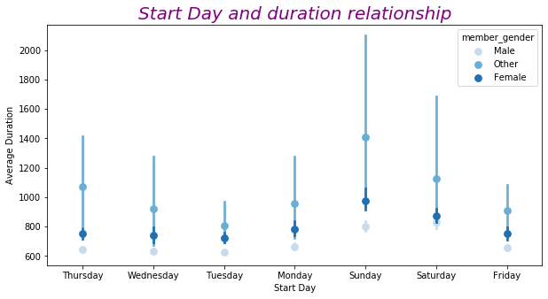

#### From the above pointplot, Other and Female gender types spent the highest duration on sunday and saturday, which causes that sundays and saturdays has the highest duration spent during the whole week.

##### Confirmation by barplot

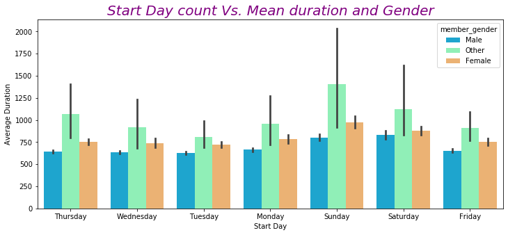

#### As we can see from the pointplot and the barplot that sunday and saturday has the most spent duration that other and female bikers did on the rides on (Sunday and Saturday) causing the most duration times through these days

##### Does customer user type still makes higher duration than subscribers in Sundays and Saturdays?

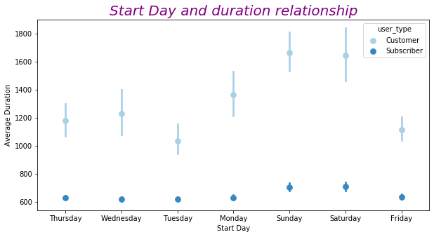

#### From this plot we can get the insight of the user type who spend more duration and the days spent on the most as well as we interpreted before, this plot to assure that customer is spending more time during trip than subscriber on sundays and saturdays the most

##### Younger bikers spent the highest duration, Female and other gender type spent the highest duration, does age category with different gender types has a different insight ?

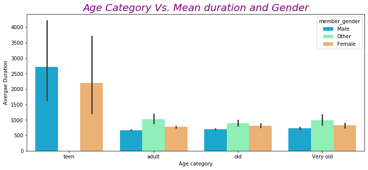

#### From this barplot we can figure that teen age (from 0 to 18) years old has no other type gender, and male teen spent more time during trip than female and teen category in general has the most duration time which make sense(depending on the youngerth e more duration spent from previous plots).However, (other gender type) as mentioned before has the most spent duration trips in Adult category and older age categories. followed by females

##### Does customer user type has higher duration in all age categories?

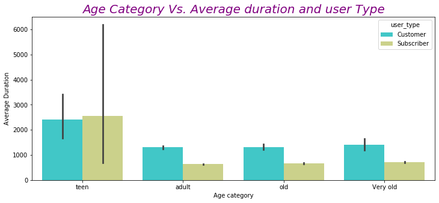

#### customers from adult and older spend more time during trip than subscribers from adult and older which reconfirom that customers at all spend more time during trip much more than subscribers, except for the teen category (0-18 Y.O) subscriber teens spent more duration than customers.

##### Reconfirmation on user type , gender and duration relationship

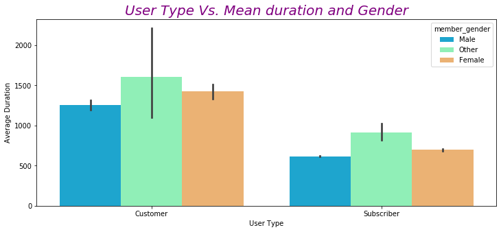